# Problem Statement: Concrete Strength Prediction

**Author :** Tulay Caglayan

### Objective:

To predict the concrete strength using the data available in file "concrete.csv". Apply feature engineering and model tuning to obtain a score above 85%.

### Resources Available:

The data file "concrete.csv" is taken from olympus.greatlearning project page DataSet tab.  
The data for this project is also available in file https://archive.ics.uci.edu/ml/machine-learning-databases/concrete/compressive/.

### Attribute Information:

Given are the variable name, variable type, the measurement unit, and a brief description. The concrete compressive strength is the regression problem. The order of this listing corresponds to the order of numerals along the rows of the database.

**Independent Input Features :**

```
1 - cement : Cement quantity by kg in m3 mixture
2 - slag : Blast Furnace Slag quantity by kg in m3 mixture
3 - ash : Fly Ash quantity by kg in m3 mixture
4 - water : Water quantity by kg in m3 mixture
5 - superplastic : Superplasticizer quantity by kg in m3 mixture
6 - coarseagg : Coarse Aggregate quantity by kg in m3 mixture
7 - fineagg : Fine Aggregate quantity by kg in m3 mixture
8 - age : Age by means of Day (1~365)
```

**Dependent Output Feature(Target):**

```
9 - strength : Concrete compressive strength in MPa
```

### Steps to Follow

1. Explore data
   - Explore data types
   - Find missing data and treat data
   - Find dublicates and treat if necessary
   - Find outliers and treat if necessary
   - Univariate analysis of the features to see distributions of the data
2. Find correlation between features
   - Bivariate and multivariate analysis by drawing plots
   - Find correlation by using heapmap
3. Make feature engineering.
   - Extract new features from existing features if any exists
   - Drop feature(s) if required
   - Get the data ready for model
   - Scale or normalize data if necessary
4. Create and tune the models
   - Suitable models will be choosen after exploring data . We will understand what is nature of data, if it is regression or classification problem and so on. We can decide models to choose after explore.
   - Create, execute and tune the models
5. Score and compare models
   - Models comparison will be done by using suitable scores.
   - KFold Cross Validation Score will be used before model hyperparameter tuning
   - After hyperparameter tuning, comparison will be made for the Test data scores which will be R squared(r2_score), mean_squared_error(MSE), mean_absolute_error(MAE) and root_mean_squared_error(RMSE)
6. Choose best model
   - Best model will be choosen by considering score comparisons.
7. Business Conclusion
   - Business meaning will be discussed and advices will be given

# Content

1. Exploratory Data Analysis
2. Bivariate Analysis
3. Feature Engineering Techniques
4. Creating and Tuning Model
5. Significance of R2 Score
6. Recommendations for Business

# Import Libraries

Before we start our work, we import all libraries which will be used throughout project

```python
# Import Libraries

# Dataframe Modul
import pandas as pd

# Preprocessing and feature engineering
from sklearn.preprocessing import StandardScaler
from sklearn.preprocessing import PolynomialFeatures

# Model selection
from sklearn.model_selection import train_test_split, GridSearchCV, RandomizedSearchCV
from sklearn.model_selection import cross_val_score

# Sequentially apply a list of transforms and a final estimator
from sklearn.pipeline import Pipeline

# Discrete random variables will be used for RandomizedSearchCV for hyperparameter tuning
from scipy.stats import randint as sp_randInt
from scipy.stats import uniform as sp_randFloat

# K-fold cross-validation
from sklearn.model_selection import KFold
from sklearn.model_selection import cross_val_score

# Decision Tree Model
from sklearn.tree import DecisionTreeRegressor

# Bagging Models
from sklearn.ensemble import RandomForestRegressor
from sklearn.ensemble import BaggingRegressor

# Boosting Models
from sklearn.ensemble import AdaBoostRegressor
from sklearn.ensemble import GradientBoostingRegressor
from xgboost import XGBRegressor
from lightgbm import LGBMRegressor

# SVM Model
from sklearn.svm import SVR

# Metrics for regression
from sklearn.metrics import mean_squared_error , mean_absolute_error ,r2_score ,explained_variance_score

# Visualize data
import matplotlib.pyplot as plt
import seaborn as sns
sns.set(color_codes=True) # adds a nice background to the graphs.

#An easy option is to configure matplotlib to automatically adjust the plot size.
from matplotlib import rcParams
rcParams.update({'figure.autolayout': True})

# Mathematic operations
import numpy as np

# Ignore warnings
import warnings
warnings.filterwarnings("ignore")
```

# 1. Exploratory Data Analysis

In this session EDA will be performed. Session includes following:

- Loading data
- Exploring data types, missing values, zero values
- Exploring descriptive sctatistic of the attributes. That will include name, central values (mean and median), standard deviation, quartiles, min, max values, analysis of the body of distributions/tails, skewness
- Exploring duplicates
- Exploring outliers
- Drawing univariate plots

```python
# Load Data
df=pd.read_csv('concrete.csv')
df.shape
```

```
(1030, 9)
```

There are 1030 rows and 9 columns.

### Explore Data Types, Missing Values and Zero Values

#### Data Types and Missing Values

```python
# Check information about data such as if exists null values for features and datatypes of each feature
df.info()
```

```
<class 'pandas.core.frame.DataFrame'>
RangeIndex: 1030 entries, 0 to 1029
Data columns (total 9 columns):
cement          1030 non-null float64
slag            1030 non-null float64
ash             1030 non-null float64
water           1030 non-null float64
superplastic    1030 non-null float64
coarseagg       1030 non-null float64
fineagg         1030 non-null float64
age             1030 non-null int64
strength        1030 non-null float64
dtypes: float64(8), int64(1)
memory usage: 72.5 KB
```

```python
# 2nd way of exploring data types
df.dtypes
```

```
cement          float64
slag            float64
ash             float64
water           float64
superplastic    float64
coarseagg       float64
fineagg         float64
age               int64
strength        float64
dtype: object
```

```python
# 2nd way of controlling missing values
df.isna().sum()
```

```
cement          0
slag            0
ash             0
water           0
superplastic    0
coarseagg       0
fineagg         0
age             0
strength        0
dtype: int64
```

#### Check zero values

```python
# check zero values
print("Number of zero values and negative for each column are:")

pd.DataFrame(df[df == 0].count(axis=0),columns=["Count Zero Values"]) \
.join(pd.DataFrame(np.round( 100*(df[df == 0].count(axis=0)/len(df)) ,0).astype(int),columns=["Percentage% Zero Values"])) \
.join(pd.DataFrame(df[df < 0].count(axis=0),columns=["Count Negative Values"]) )
```

```
Number of zero values and negative for each column are:
```

|  | Count Zero Values | Percentage% Zero Values | Count Negative Values |
| --- | --- | --- | --- |
| cement | 0 | 0 | 0 |
| slag | 471 | 46 | 0 |
| ash | 566 | 55 | 0 |
| water | 0 | 0 | 0 |
| superplastic | 379 | 37 | 0 |
| coarseagg | 0 | 0 | 0 |
| fineagg | 0 | 0 | 0 |
| age | 0 | 0 | 0 |
| strength | 0 | 0 | 0 |

#### Insights for datatypes, missing values and zero values:

- There is **No missing** values for any feature.
- There are 8 independent features, 1 dependent feature named **strength**.
- There are **1 int64, 8 float64** type features.
- There is no categorical feature or object feature. All features are numerical
- Dependent feature is float including continues values. So this is a **Regression** problem
- There is no **negative** values
- There are **zero values** for slag, ash and superplastic . Number of zero values for all three features are too much each being more than %35 of the data. There cannot be so much error in data. They should be actual values and they are not missing values. Some mixtures may not have slag, ash or superplastic . This should be normal case for mixtures. It is not must to have slag, ash and superplastic for mixtures . I won't drop rows with zero values since I will loose nearly half of the data. I won't treat zero values too since they are normal to have zero value for these 3 features .

```python
df.head(3)
```

|  | cement | slag | ash | water | superplastic | coarseagg | fineagg | age | strength |
| --- | --- | --- | --- | --- | --- | --- | --- | --- | --- |
| 0 | 141.3 | 212.0 | 0.0 | 203.5 | 0.0 | 971.8 | 748.5 | 28 | 29.89 |
| 1 | 168.9 | 42.2 | 124.3 | 158.3 | 10.8 | 1080.8 | 796.2 | 14 | 23.51 |
| 2 | 250.0 | 0.0 | 95.7 | 187.4 | 5.5 | 956.9 | 861.2 | 28 | 29.22 |

- All features have numeric continues values
- Dependent feature is float type including continues values. So this is a **Regression** problem
- There is no categorical feature in data
- It seems that every feature has different scale. But in the problem definition, it is given that all features are measures in kg except age feature. So, no need to scale or normalize data

### Descriptive Statistic

This part will include description of the attributes which include name, range of values observed, central values (mean and median), standard deviation and quartiles , skewness of data

```python
df.describe().T
```

|  | count | mean | std | min | 25% | 50% | 75% | max |
| --- | --- | --- | --- | --- | --- | --- | --- | --- |
| cement | 1030.0 | 281.167864 | 104.506364 | 102.00 | 192.375 | 272.900 | 350.000 | 540.0 |
| slag | 1030.0 | 73.895825 | 86.279342 | 0.00 | 0.000 | 22.000 | 142.950 | 359.4 |
| ash | 1030.0 | 54.188350 | 63.997004 | 0.00 | 0.000 | 0.000 | 118.300 | 200.1 |
| water | 1030.0 | 181.567282 | 21.354219 | 121.80 | 164.900 | 185.000 | 192.000 | 247.0 |
| superplastic | 1030.0 | 6.204660 | 5.973841 | 0.00 | 0.000 | 6.400 | 10.200 | 32.2 |
| coarseagg | 1030.0 | 972.918932 | 77.753954 | 801.00 | 932.000 | 968.000 | 1029.400 | 1145.0 |
| fineagg | 1030.0 | 773.580485 | 80.175980 | 594.00 | 730.950 | 779.500 | 824.000 | 992.6 |
| age | 1030.0 | 45.662136 | 63.169912 | 1.00 | 7.000 | 28.000 | 56.000 | 365.0 |
| strength | 1030.0 | 35.817961 | 16.705742 | 2.33 | 23.710 | 34.445 | 46.135 | 82.6 |

```python
df.skew()
```

```
cement          0.509481
slag            0.800717
ash             0.537354
water           0.074628
superplastic    0.907203
coarseagg      -0.040220
fineagg        -0.253010
age             3.269177
strength        0.416977
dtype: float64
```

**Insights for Descriptive Statistic**

### Explore dublicates

Dublicates based on all columns are explored

```python
# Select duplicate rows except first occurrence based on all columns
print( "There are %s dublicates except first occurences base on all columns.Top 10 of them are:" % len(df[df.duplicated()]))
df[df.duplicated()].head(10)

# There is nothing to do with these dublicates here since mixtures can be made for same mixture amounts
# I won't drop dublicates
```

```
There are 25 dublicates except first occurences base on all columns.Top 10 of them are:
```

|  | cement | slag | ash | water | superplastic | coarseagg | fineagg | age | strength |
| --- | --- | --- | --- | --- | --- | --- | --- | --- | --- |
| 278 | 425.0 | 106.3 | 0.0 | 153.5 | 16.5 | 852.1 | 887.1 | 3 | 33.40 |
| 298 | 425.0 | 106.3 | 0.0 | 153.5 | 16.5 | 852.1 | 887.1 | 3 | 33.40 |
| 400 | 362.6 | 189.0 | 0.0 | 164.9 | 11.6 | 944.7 | 755.8 | 3 | 35.30 |
| 420 | 362.6 | 189.0 | 0.0 | 164.9 | 11.6 | 944.7 | 755.8 | 3 | 35.30 |
| 463 | 362.6 | 189.0 | 0.0 | 164.9 | 11.6 | 944.7 | 755.8 | 56 | 77.30 |
| 468 | 252.0 | 0.0 | 0.0 | 185.0 | 0.0 | 1111.0 | 784.0 | 28 | 19.69 |
| 482 | 425.0 | 106.3 | 0.0 | 153.5 | 16.5 | 852.1 | 887.1 | 91 | 65.20 |
| 493 | 362.6 | 189.0 | 0.0 | 164.9 | 11.6 | 944.7 | 755.8 | 91 | 79.30 |
| 517 | 425.0 | 106.3 | 0.0 | 153.5 | 16.5 | 852.1 | 887.1 | 56 | 64.30 |
| 525 | 362.6 | 189.0 | 0.0 | 164.9 | 11.6 | 944.7 | 755.8 | 28 | 71.30 |

#### Insights for dublicates

- There are 25 dublicates based on all columns.
- There is nothing to do with these dublicates here since mixtures can be made for same mixture amounts. They are not errors. They seem they are correct data
- I won't drop or immute dublicates

### Explore Outliers

An outlier is an observation that is unlike the other observations. Outliers can have many causes, such as:

- Measurement or input error.
- Data corruption.
- True outlier observation

Since our data is not Gaussian distributed , we will use IQR(InterQuartile Range) for describing outliers. The IQR is calculated as the difference between the 75th and the 25th percentiles of the data

The IQR can be used to **identify outliers by defining limits on the sample values that are 1.5 times of the IQR below the 25th percentile or above the 75th percentile**

```python
# Identify Outliers using IQR
def outliers_by_IQR(df):

    iqr_list ={}

    for col in df.columns :
        # calculate interquartile range
        q25, q50, q75 = np.percentile(df[col], 25),np.percentile(df[col], 50), np.percentile(df[col], 75)
        iqr = q75 - q25

        # calculate the outlier cutoff
        cut_off = iqr * 1.5
        lower, upper = q25 - cut_off, q75 + cut_off

        # identify outliers
        outliers = [x for x in df[col] if x < lower or x > upper]

        # Outliers percentage of data by IQR
        perc_by_IQR = 100 * len(outliers)/ len(df[col])

        # Count of Outliers
        count_outliers = len(outliers)

        # Distinct Outlier values
        outlier_set = ''
        if outliers:
            outlier_set = sorted(set(outliers))

        iqr_list[col] = { 'Min_Whisker' : lower,
                          '%25' : q25,
                          '%50' : q50,
                          '%75' : q75,
                          'Max_Whisker' : upper,
                          'IQR' : iqr,
                          'Outlier_Count' : count_outliers,
                          '%Outlier_by_IQR' : '{:.2f}'.format(np.round(perc_by_IQR,2)) ,
                          'Distinct_Outlier_Values' : outlier_set
                        }
    df_result = pd.DataFrame.from_dict(iqr_list, orient='index')
    df_result = df_result \
                 .sort_values(by=['%Outlier_by_IQR'], ascending=False) \
                 .style.apply(lambda x:['background: lightgreen' if x.name == '%Outlier_by_IQR' else '' for i in x], axis=0)
    return df_result

# Print Outlier percentages by IQR
outliers_by_IQR(df)
```

|  | Min_Whisker | %25 | %50 | %75 | Max_Whisker | IQR | Outlier_Count | %Outlier_by_IQR | Distinct_Outlier_Values |
| --- | --- | --- | --- | --- | --- | --- | --- | --- | --- |
| age | -66.5 | 7 | 28 | 56 | 129.5 | 49 | 59 | 5.73 | [180, 270, 360, 365] |
| superplastic | -15.3 | 0 | 6.4 | 10.2 | 25.5 | 10.2 | 10 | 0.97 | [28.2, 32.2] |
| water | 124.25 | 164.9 | 185 | 192 | 232.65 | 27.1 | 9 | 0.87 | [121.8, 236.7, 237.0, 246.9, 247.0] |
| fineagg | 591.375 | 730.95 | 779.5 | 824 | 963.575 | 93.05 | 5 | 0.49 | [992.6] |
| strength | -9.9275 | 23.71 | 34.445 | 46.135 | 79.7725 | 22.425 | 4 | 0.39 | [79.99, 80.2, 81.75, 82.6] |
| slag | -214.425 | 0 | 22 | 142.95 | 357.375 | 142.95 | 2 | 0.19 | [359.4] |
| cement | -44.0625 | 192.375 | 272.9 | 350 | 586.438 | 157.625 | 0 | 0.00 |  |
| ash | -177.45 | 0 | 0 | 118.3 | 295.75 | 118.3 | 0 | 0.00 |  |
| coarseagg | 785.9 | 932 | 968 | 1029.4 | 1175.5 | 97.4 | 0 | 0.00 |  |

- For percentage of data, age feature has the most outlier percentage of data compared to other features.
- Superplastic is second and water is third.
- Cement, ash and coarseagg have no outlier

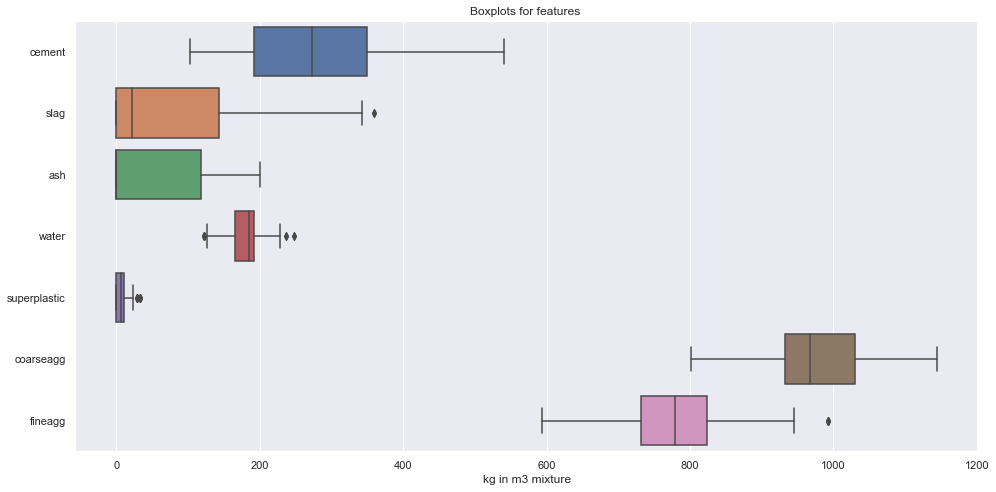

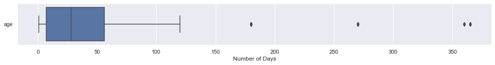

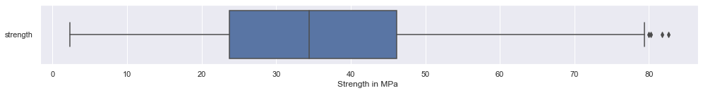

```python
# verify outliers by using BoxPlot
"""
# show as subplots seperate for all features
fig, axes = plt.subplots(ncols=1, nrows=9, figsize=[10, 16])

for ax, col in zip(np.ravel(axes), features) :
    sns.boxplot(data= df[col], orient='h', ax=ax )
    ax.set_xlabel(col)
    ax.set_ylabel('')

plt.show()
"""

# show features having same measure(kg in mixture) in one plot for comparison also
plt.figure(figsize=[14,7])
sns.boxplot(data= df[["cement","slag","ash","water","superplastic","coarseagg","fineagg"]], orient='h' )
plt.title("Boxplots for features ")
plt.xlabel("kg in m3 mixture")
plt.show()

plt.figure(figsize=[14,2])
sns.boxplot(data= df[["age"]], orient='h' )
plt.xlabel("Number of Days")
plt.show()

plt.figure(figsize=[14,2])
sns.boxplot(data= df[["strength"]], orient='h' )
plt.xlabel("Strength in MPa ")
plt.show()
```

### Univariate plots - Drawing histograms for the features

```python
# Take list of all features
features = df.columns
```

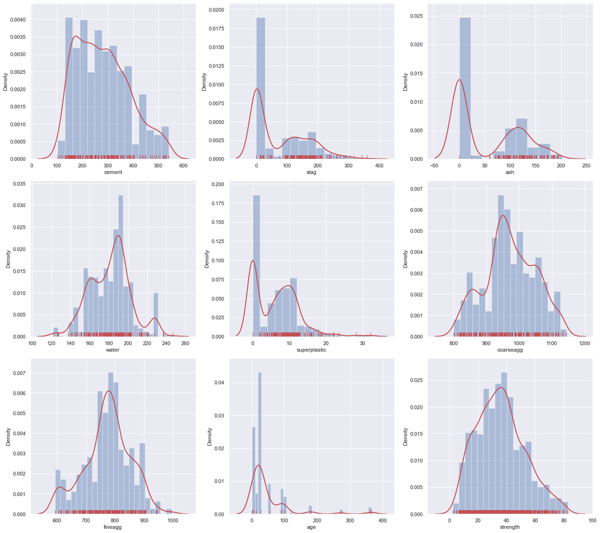

```python
# plot histogram of the features
fig, axes = plt.subplots(ncols=3, nrows=3, figsize=[18, 16])

for ax, col in zip(np.ravel(axes), features) :
    sns.distplot(df[col],rug=True,kde=True,
                 rug_kws={"color": "r"},
                 kde_kws={"color": "r", "lw": 2, "label": "KDE"}, ax=ax )
    ax.set_xlabel(col)

plt.show()
```

### Univariate plots - Drawing countplot

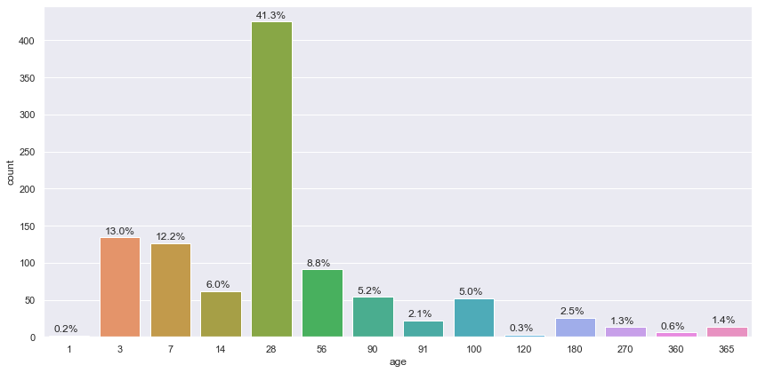

```python
# Count plot
plt.figure(figsize=(12,6))
total = len(df)
ax= sns.countplot(x='age', data=df)


for p in ax.patches:
        ax.annotate('{:.1f}%'.format(100*p.get_height()/total), (p.get_x()+0.1, p.get_height()+5))

plt.show()
```

#### Insighst for countplot:

- 41.3% of data is at age of 28 days
- In general age is between 3 - 56 days
- There are outliers but they are not errors. Outliers are actual values since there is no anomally for them

# 2. Bivariate Analysis

This session includes following:

- Bi-variate analysis between the predictor variables and between the predictor variables and target column.
- Comments for relationships and degree of relation if there is any.
- Drawing plots for visualizing the analysis using pair plots, histograms, or density curves
- Drawing heatmap to see correalation between features
- Writing insights/business understanding

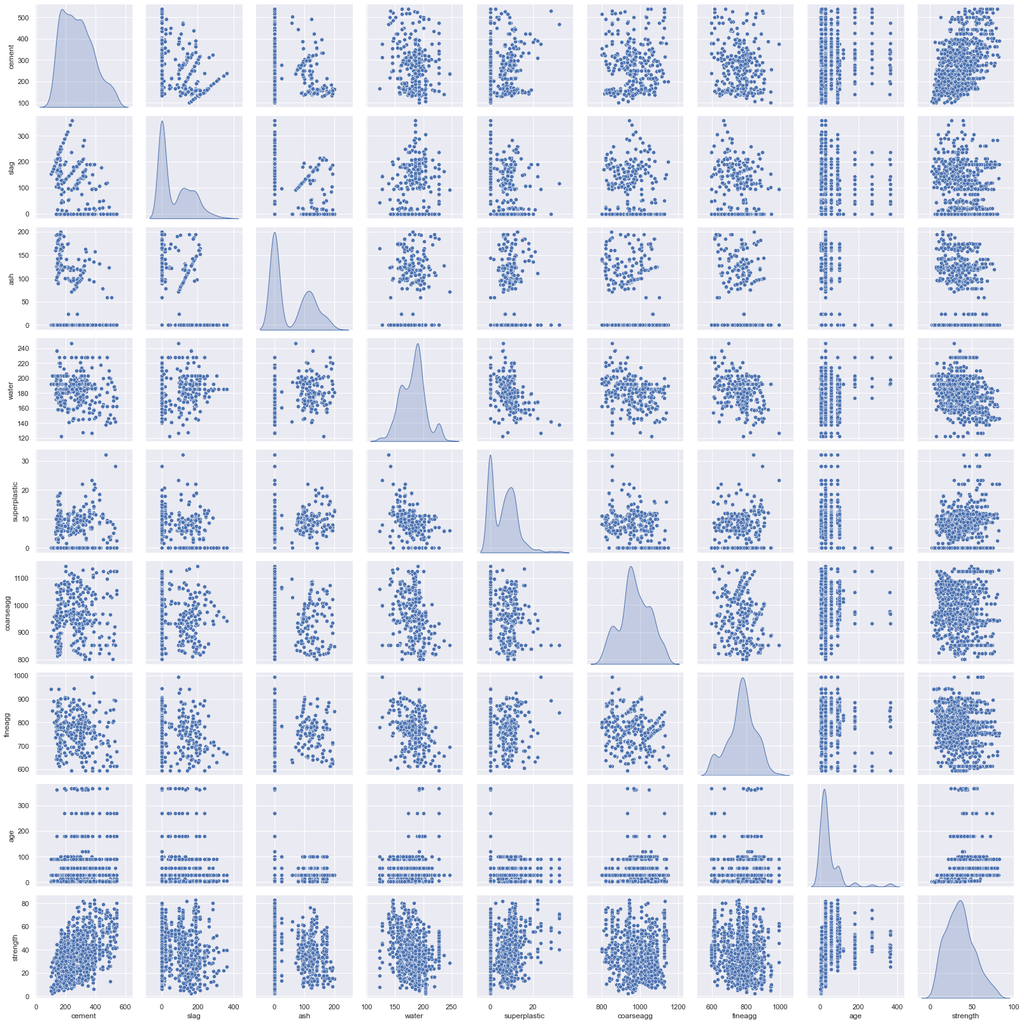

```python
# Visualize the analysis using pair plots ,analysis between predictor variables and target column.
sns.pairplot(df, diag_kind='kde' );
```

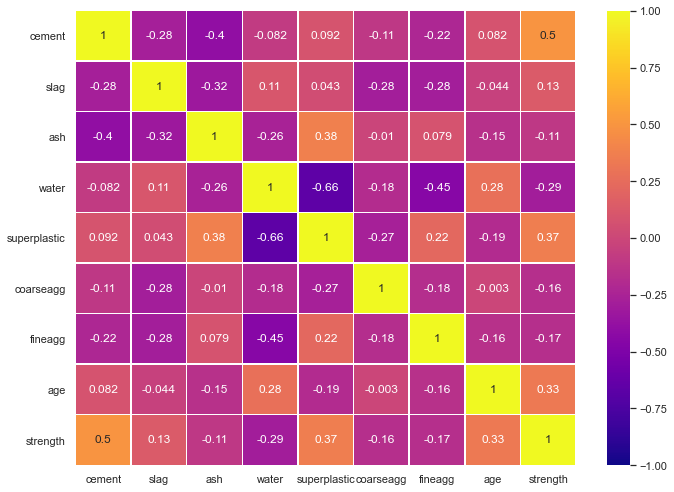

```python
# Draw heatmaps
ax =plt.figure(figsize=(10,7))
sns.heatmap(df.corr(),linewidths=.5, annot=True,cmap='plasma',vmin=-1,vmax=1);
```

#### Insights for heatmap

- There is negative correleation between "superplastic" and "water". Coorrelation is -0.66
- There is positive correlation between "strength" and "cement" with value of 0.5
- We may say there is slightly negative correlation between "water" and "fineagg", since it's absolute value is 0.45 and close to 0.5
- There is no correlation between other features since there is no abs(value) >= 0.5

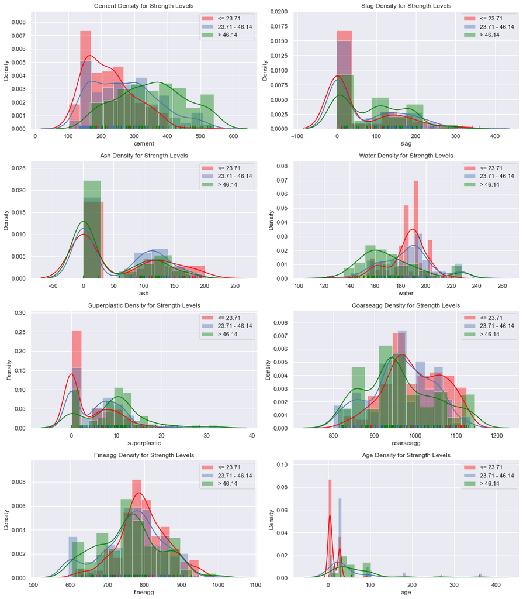

```python
# Compare dependent feature strength with independent features by density curves

# I want to see distribution of features within quarters of strength and outside or quarters of strength
# Quarters for strength: 25th=23.71, 50th=34.45, 75th=46.14

q1 = 23.71
q3 = 46.14

fig, axes = plt.subplots(ncols=2, nrows=4, figsize=[14, 16])

for ax, col in zip(np.ravel(axes), features) :
    sns.distplot(df[ (df["strength"] < q1)][col], color='red', label='<= '+str(q1) ,rug=True, ax=ax )
    sns.distplot(df[ (df["strength"] >= q1) & (df["strength"] <= q3)][col], color='b', label=str(q1)+' - '+str(q3) ,rug=True, ax=ax )
    sns.distplot(df[ (df["strength"] > q3) ][col], color='green', label='> '+str(q3) ,rug=True, ax=ax )
    ax.legend()
    ax.set_title(col.capitalize() +" Density for Strength Levels")

plt.show()
```

#### Insights for comparison dependent feature with independent features

- Data with more cement is usually stronger than less cement.
- There is no effect of slag and ash on strength
- There is negative effect of water on strength. More water decreases strength and less water increases strength
- There is slight effect of superplastic on strength. More superplastic leads to more strength , less superplastic less strength
- We can say there is no effect of fineagg and coarseagg on strength, since effect is too small that it can be ignored
- The older the mixture, the more strengther it is . Mixture with less age is weaker
- There are zero values for slag, ash and superplastic

# 3. Feature Engineering Techniques

This "feature engineering" session includes following:

- Identif opportunities to extract new features from existing features if any exists  
  Hint: Consider a dataset with two features length and breadth. We can extract a new feature Area which would be length * breadth.
- Drop feature(s) if required
- Get the data model ready
- Do a train test split
- Decide on the complexity of the model, should it be a simple linear model in terms of parameters or would a quadratic or higher degree.

```python
# Before starting feature engineering, we keep our original dataframe by copying to another dataframe
# in order not to damage original one. We will work on copied dataframe after that

df_new = df.copy()
```

### Derive New Features and Drop If Required

I tried models with new features. But either they overfitted for train data or R2 Score performance is decreased for test data.

I tried by dropping features. After I executed my models, models' test performances went down.

I tried polynomial Features and tested on models . Model performances went down. So, I returned back

Details are as below

#### Define Function

This function will be used after each feature add and each feature drop. Function will fit model, score model and save results. Later on, results will be compared to decide for adding or dropping features

```python
# I chosed XGBoost to try since at last XGBoost is my best model
# I try to improve performance by adding new features or dropping  current features

# set model object to test for features
model_feature_test = XGBRegressor(learning_rate=0.15,n_estimators=350, max_depth=5,verbosity=0)

# set scaler object
scaler = StandardScaler()

# initialize scores dictionary
feature_scores = {}

def feature_test(X, y, name, imp_flag=0):

    # split data
    X_train, X_test, y_train, y_test = train_test_split(X, y, test_size=.3, random_state=7)

    # scale
    X_train = scaler.fit_transform(X_train)
    X_test = scaler.transform(X_test)

    # fit
    model_feature_test.fit(X_train, y_train)

    # scores
    train_score = model_feature_test.score(X_train, y_train)
    test_score = model_feature_test.score(X_test, y_test)

    new_feature_importance = ''
    if imp_flag == 1:
        new_feature_importance = model_feature_test.feature_importances_[-1]

    # save result
    feature_scores[name] = [train_score,test_score, new_feature_importance]
```

#### With Original data

```python
X = df_new.drop('strength',axis=1)
y = df_new['strength']

# Fit data on model and save score
feature_test(X, y,"WITH ORIGINAL" )
```

#### Drive Polynomial Features

```python
#  Drive new features by using PolynomialFeatures from sklearn

X = df_new.drop('strength',axis=1)
y = df_new['strength']

poly = PolynomialFeatures(2) #degree 2
X = poly.fit_transform(X)

# Fit data on model and save score
feature_test(X, y,"POLYNOMIAL FEATURES" )
```

#### Derive Feature Pairs

```python
#  Drive new features
#df_new["superplastic_coarseagg"] = df_new['coarseagg'] * df_new['superplastic']

# I want to drive new feature by using slag and ash.
# There is no effect of slag and ash on strength but together may have effect
#df_new['ash_slag'] = df_new['ash'] + df_new['slag']

#  water has negative effect for coarseagg and water. Together may effect better
#df_new["water_coarseagg"] =  df_new['water'] * df_new["coarseagg"]

# There is negative effect for coarseagg and fineagg. Together may effect better
#df_new["coarseagg_fineagg"] = df_new['coarseagg'] * df_new['fineagg']


# Try to find pairs which will increase score

independent_features = df_new.drop('strength',axis=1).columns

# ***** try with new feature by pairs ****
for f1 in independent_features: # We search for the pair which will increase the performance of the model
    for f2 in independent_features:

        if ((f1 != f2 ) and
           ((f1 + '_' + f2) not in feature_scores) and
           ((f2 + '_' + f1) not in feature_scores)):

            X = df_new[independent_features]
            y = df_new['strength']

            # add new feature
            new_feature_name = f1 + '_' + f2
            # instead of multiply, plus results were better
            X[new_feature_name] =  X[f1] + X[f2]

            # Fit data on model and save score
            feature_test(X, y, new_feature_name, 1)
```

#### Drop Features

```python
# Drop features

# There is no effect of ash and slag on strength .We can drop ash and slag
# There is a little effect of coarseagg, fineagg in negative way. We can try to drop them

for col in ['coarseagg','fineagg', 'ash','slag' ]:
    X = df_new.drop('strength',axis=1)
    y = df_new['strength']

    X.drop([col],axis=1,inplace=True)

    # Fit data on model and save score
    feature_test(X, y,"DROP FEATURE " + col )
```

```python
# compare results  after add - drop features
pd.DataFrame.from_dict(feature_scores, orient='index',columns=["train_score","test_score","new_feature_importance"])\
        .sort_values(by=['test_score','new_feature_importance'], ascending=False)
```

|  | train_score | test_score | new_feature_importance |
| --- | --- | --- | --- |
| DROP FEATURE coarseagg | 0.993933 | 0.950266 |  |
| slag_coarseagg | 0.994885 | 0.949418 | 0.0271902 |
| water_coarseagg | 0.994857 | 0.948999 | 0.0209699 |
| ash_coarseagg | 0.994831 | 0.948577 | 0.0343599 |
| WITH ORIGINAL | 0.994936 | 0.948326 |  |
| superplastic_coarseagg | 0.994856 | 0.948226 | 0.0125116 |
| water_fineagg | 0.994893 | 0.947644 | 0.0521708 |
| superplastic_fineagg | 0.994774 | 0.947610 | 0.0158296 |
| ash_superplastic | 0.994894 | 0.947517 | 0.146703 |
| ash_age | 0.994969 | 0.946040 | 0.0129392 |
| ash_water | 0.994821 | 0.945962 | 0.2719 |
| cement_superplastic | 0.994864 | 0.945763 | 0.399136 |
| cement_fineagg | 0.994830 | 0.945677 | 0.0225756 |
| cement_water | 0.994864 | 0.945451 | 0.0198642 |
| cement_coarseagg | 0.995008 | 0.945112 | 0.0180066 |
| slag_fineagg | 0.994905 | 0.944957 | 0.0256946 |
| cement_ash | 0.994807 | 0.944351 | 0.124596 |
| slag_age | 0.995056 | 0.943767 | 0.0709293 |
| coarseagg_age | 0.995167 | 0.943682 | 0.00626033 |
| slag_superplastic | 0.994896 | 0.943405 | 0.0946598 |
| water_age | 0.995152 | 0.943185 | 0.00782022 |
| DROP FEATURE ash | 0.994758 | 0.942877 |  |
| fineagg_age | 0.995064 | 0.942706 | 0.00537712 |
| ash_fineagg | 0.994810 | 0.941769 | 0.044873 |
| water_superplastic | 0.994792 | 0.941537 | 0.0699315 |
| superplastic_age | 0.995115 | 0.941488 | 0.382135 |
| slag_water | 0.994816 | 0.941444 | 0.0477 |
| slag_ash | 0.994837 | 0.940135 | 0.100173 |
| cement_age | 0.995084 | 0.939896 | 0.230735 |
| coarseagg_fineagg | 0.994782 | 0.939757 | 0.0408659 |
| DROP FEATURE fineagg | 0.994693 | 0.936898 |  |
| POLYNOMIAL FEATURES | 0.995324 | 0.936766 |  |
| DROP FEATURE slag | 0.994786 | 0.935522 |  |
| cement_slag | 0.994991 | 0.924509 | 0.628668 |

#### Insights for adding new features and dropping current features:

- With POLYNOMIAL FEATURES, performance of model on Test data decreased. Train data about to overfit
- By adding new feature pairs descreases performance of model on Test data. 3 of them slightly seems better on test data than original data. But not big difference. Also these 3 new features' importances are too small. No need to increase complexity of model. New Feature "ash_superplastic" and "cement_superplastic" have valuable importances. They have also good test scores. Ash does not effect on Strengh. Maybe, we can gain information from ash by adding with superplastic. I will only add "ash_superplastic" as new feature which is to be wait to increase Test performance a bit
- By DROPPING fineagg, ash, slag, performance of model on Test data decreased.
- Dropping coarseagg increased Test score. I will drop "coarseagg" feature
- Best result is for "DROP FEATURE coarseagg"
- **As a result, I will add new feature "ash_superplastic". I will drop feature "coarseagg" and go on with new data**

```python
# we keep our original dataframe by copying to another dataframe
# in order not to damage original one. We will work on copied dataframe after that

df_new = df.copy()

df_new["ash_superplastic"] = df_new['ash'] + df_new['superplastic']
df_new.drop(["coarseagg"],axis=1,inplace=True)
```

### Do a train test split

Create the training set and test set in a ratio of **70:30**. Make sure and verify distribution of classes is the same in the full dataset and train test split data.

Parameter **test_size=0.30** will be used for split  
Parameter **random_state=7** will be used for split

```python
# Use random_state=7 , Create the training set and test set in a ratio of 70:30.
# 0.30 for test , 0.70 for Train data set

X_train, X_test, y_train, y_test = train_test_split(df_new.drop('strength',axis=1), df_new['strength'], \
                                                    test_size=.3, random_state=7)
X_train.shape, X_test.shape
```

```
((721, 8), (309, 8))
```

```python
#Make sure and verify distribution of classes is the same in the full dataset and train test split data.

data_cnt = df_new.shape[0]
print('Train data size = {} , Test data size = {}'.format(len(X_train),len(X_test)))
print('Train data ratio = {:.2f}, Test data ratio = {:.2f}'.format(len(X_train)/data_cnt,len(X_test)/data_cnt))
```

```
Train data size = 721 , Test data size = 309
Train data ratio = 0.70, Test data ratio = 0.30
```

### Scale Data

```python
# we will use standard scaler on data
scaler = StandardScaler()
X_train = scaler.fit_transform(X_train)
X_test = scaler.transform(X_test)
```

### Decide on the complexity of the model

- Model will be **regression** model since this is a regresion problem having continues target values . Target does not have categorical values
- **Model cannot be Linear Regression model since there is no linear relation between data**
- We will work with following algorithms:
  - Decision Tree,
  - Ensemble models such as;
    - Random Forest
    - Bagging,
    - Boosting,
      - GradientBoostingRegressor: I will use this boosting model
      - XGBRegressor : I will use this boosting model
      - LGBMRegressor : Light GBM is sensitive to overfitting and can easily overfit small data. I don't prefer to use since our data is small
      - AdaBoostRegressor: Performs worse when irrelevant features are included. In our case, since features are irrevalent(no correlation), we expect this model to be worst . So I won't try this model
  - SVM: Support Vector Machine. SVR algorithm will be used from SVM modul

# 4. Creating and Tuning Model

This session will include work for model creation and tuning:

- Suitable algorithms will be choosen for the project. At least 3 algorithms, one bagging and one boosting based algorithms wil be used and accuracy on testing set will be performed for 90% accuracy
- Kfold Cross-Validation will be used to evaluate model performance.
- Appropriate metrics will be use to compare models
- Techniques employed to squeeze that extra performance out of the model without making it overfit. Instead of Grid Search, Random Searchwill be used since Random Search performance is better than Grid Search
- After hyperparameter tuning and models metrics will be compared by using DataFrame

Regression algorithms may be used are :

**Bagging Models :**

- **RandomForestRegressor** : Ensemble model made of many decision trees using bootstrapping, random subsets of features, and average voting to make predictions.
- **BaggingRegressor** : (Bootstrap Aggregation) Bagging in ensemble machine learning takes several weak models, aggregating the predictions to select the best prediction. When base_estimator parameter is not set, the base estimator is set to DecisionTreeRegressor

**Boosting Models :**

- **GradientBoostingRegressor** : Supervised machine learning technique which produces a prediction model in the form of an ensemble of weak prediction models, typically decision trees.
- **XGBRegressor** : XGBoost is an implementation of gradient boosted decision trees designed for speed and performance
- **LGBMRegressor**: Light GBM is a gradient boosting framework that uses tree based learning algorithm. Light GBM grows tree vertically while other algorithm grows trees horizontally. It is not advisable to use LGBM on small datasets. Light GBM is sensitive to overfitting and can easily overfit small data. I don't prefer to use since our data is small
- **AdaBoostRegressor**:(Adaptive Boosting) performs worse when irrelevant features are included. In our case , since features are irrevalent, we expect this model to be worst . So I won't try this model

**DecisionTree:**

- **DecisionTreeRegressor**: Model breaks down a dataset into smaller and smaller subsets while at the same time an associated decision tree is incrementally developed. The final result is a tree with decision nodes and leaf nodes.

**SVM Model**

- **SVR** : Epsilon-Support Vector Regression

Note: Our choosen models are not sensitive to outliers

### Metrics and Scoring

Before tuning, cross_valudation_score will be used to choose models.

After tune models, since problem is regression problem, metrics on Test data will be used from sklearn.metrics module are:

- **R Square :** : R Square measures how much of variability in dependent variable can be explained by the model. It is square of Correlation Coefficient(R). R Square is calculated by the sum of squared of prediction error divided by the total sum of square which replace the calculated prediction with mean. Best possible score is 1.0 and it can be negative in case the model is arbitrarily worse
- **Mean squared error(MSE)** : While R Square is a relative measure of how well the model fits dependent variables, Mean Square Error is an absolute measure of the goodness for the fit. MSE is calculated by the sum of square of prediction error which is real output minus predicted output and then divide by the number of data points
- **Root Mean Square Error(RMSE)**: Root Mean Square Error(RMSE) is the square root of MSE. It is used more commonly than MSE because firstly sometimes MSE value can be too big to compare easily. Secondly, MSE is calculated by the square of error, and thus square root brings it back to the same level of prediction error and make it easier for interpretation.
- **Mean absolute error(MAE)** : Mean Absolute Error(MAE) is similar to Mean Square Error(MSE). However, instead of the sum of square of error in MSE, MAE is taking the sum of absolute value of error.Compare to MSE or RMSE, MAE is a more direct representation of sum of error terms. MSE gives larger penalisation to big prediction error by square it while MAE treats all errors the same.

### Metrics Function

Reporting function will do following :

- Calculate r2-score and other metrics
- Store each metric for models in dictionary in order to compare results as dataframe

```python
# report_model function will be used to draw report for models and
# to store each metric for models in order to compare results

tuned_model_metrics = {}

def save_metrics(X_train, X_test, y_train, y_test,  model_name, model):

    y_pred_test = model.predict(X_test)
    y_pred_train = model.predict(X_train)


    # Save metrics
    tuned_model_metrics[model_name] = {
             'MAE(Train)': '{:.2f}'.format(np.round(mean_absolute_error(y_train, y_pred_train),2)),
             'MAE(Test)': '{:.2f}'.format(np.round(mean_absolute_error(y_test, y_pred_test),2)),
             'MSE(Train)': '{:.2f}'.format(np.round(mean_squared_error(y_train, y_pred_train),2)),
             'MSE(Test)': '{:.2f}'.format(np.round(mean_squared_error(y_test, y_pred_test),2)),
             'RMSE(Train)': '{:.2f}'.format(np.round(np.sqrt(mean_squared_error(y_train, y_pred_train)),2)),
             'RMSE(Test)': '{:.2f}'.format(np.round(np.sqrt(mean_squared_error(y_test, y_pred_test)),2)),
             'R2-Score(Train)': '{:.2f}'.format(np.round(r2_score(y_train, y_pred_train),2)),
             'R2-Score(Test)': '{:.2f}'.format(np.round(r2_score(y_test, y_pred_test),2))
            }


## Save Cross validation results
cross_val_scores = {}

def save_cross_val_score(scores, model_name):
    # Save cv score
    cross_val_scores[model_name] = {
             'cross_val_score mean': '{:.2f}'.format(np.round(np.mean(scores),2)),
             'cross_val_scores': '{}'.format(scores)
            }
```

### Create Models and Calculate Kfold Cross Validation Scores

In this session, we will create models without hyperparameter tuning by default values.

Kfold Cross-Validation scores will be used to evaluate model performance

We will compare results for cross validation scores of the models

```python
# Constants
KFOLD = 5
RANDOM_STATE = 7

# Initialize KFold. Same KFold will be used for all models in order to make fair comparison
# n_splits : Number of splitting iterations.
kfold = KFold(n_splits=KFOLD, random_state=RANDOM_STATE)
```

```python
# Decision Tree
model = DecisionTreeRegressor()

#Kfold cross validation scores
model_cross_val_scores = cross_val_score(model, X_train, y_train, cv=kfold, scoring='r2')

# Save scores in order to compare
save_cross_val_score(model_cross_val_scores , "Decision Tree")
```

```python
# RandomForest
model = RandomForestRegressor()

#Kfold cross validation scores
model_cross_val_scores = cross_val_score(model, X_train, y_train, cv=kfold, scoring='r2')

save_cross_val_score(model_cross_val_scores , "Random Forest")
```

```python
# BaggingRegressor
model = BaggingRegressor()

#Kfold cross validation scores
model_cross_val_scores = cross_val_score(model, X_train, y_train, cv=kfold, scoring='r2')

# Save scores in order to compare
save_cross_val_score(model_cross_val_scores , "Bagging")
```

```python
# GradientBoostingRegressor
model = GradientBoostingRegressor()

#Kfold cross validation scores
model_cross_val_scores = cross_val_score(model, X_train, y_train, cv=kfold, scoring='r2')

# Save scores in order to compare
save_cross_val_score(model_cross_val_scores , "Gradient Boosting")
```

```python
# XGBoost
model = XGBRegressor()

#Kfold cross validation scores
model_cross_val_scores = cross_val_score(model, X_train, y_train, cv=kfold, scoring='r2')

# Save scores in order to compare
save_cross_val_score(model_cross_val_scores , "XGBoost")
```

```python
# SVM
model = SVR(verbose=False)

#Kfold cross validation scores
model_cross_val_scores = cross_val_score(model, X_train, y_train, cv=kfold, scoring='r2')

# Save scores in order to compare
save_cross_val_score(model_cross_val_scores , "SVM")
```

### Compare Models with Cross Validation Scores

```python
pd.set_option('display.max_columns', None)
pd.set_option('max_colwidth', -1) # to see all data inside cell
# Scores of all the models by building a dataframe with model names as row index and
#all the metrics calculated as columns
df_result =pd.DataFrame.from_dict(cross_val_scores, orient='index')
df_result= df_result.sort_values(by=['cross_val_score mean'], ascending=False) \
            .style.apply(lambda x: ['background: yellow' \
                                    if x.name == 'cross_val_score mean' else '' for i in x], axis=0)
df_result
```

|  | cross_val_score mean | cross_val_scores |
| --- | --- | --- |
| XGBoost | 0.90 | [0.89554555 0.87205112 0.93047005 0.89970595 0.91063491] |
| Random Forest | 0.89 | [0.85799313 0.89230023 0.9056145 0.90330204 0.87702887] |
| Gradient Boosting | 0.89 | [0.88048012 0.85923204 0.90299099 0.90865618 0.8943061 ] |
| Bagging | 0.87 | [0.84035125 0.8739892 0.88993107 0.89031985 0.84068341] |
| Decision Tree | 0.78 | [0.69421037 0.77554894 0.83169337 0.82241879 0.79494584] |
| SVM | 0.60 | [0.62395195 0.60715588 0.59094357 0.62735255 0.55762984] |

- According to KFold cross validation scores, **XGBoost** is the best model with cross validation score of **0.90**

#### Fit Best Model of Kfold Cross Validation on Train data and Score on Test data

```python
# According to cross validation score our best model is XGBoost
# Fit model and get score on test data

model = XGBRegressor()
model.fit(X_train, y_train)

print ("Test score for best model is ", model.score(X_test, y_test) )
```

```
Test score for best model is  0.9456813941000766
```

### Tune Models

- For hyperparameter tuning, GridSearchCV and(or) RandomizedSearchCV will be used
- **What is Hyper Parameter?** : Model configuration argument specified by the developer to guide the learning process for a specific dataset. Hyperparameters are different from parameters. Parameters are learned automatically from data; hyperparameters are set manually to help guide the learning process
- **What is Hyper Parameter Tuning?** : It is often required to search for a set of hyperparameters that result in the best performance of a model on a dataset. This is called hyperparameter optimization, hyperparameter tuning
- **What is Grid Search** :Every combination of a preset list of values of the hyper-parameters is tried and the model is evaluated for each combination.
- **What is Randomized Search?** : Random combination of predefined bounded domain of the hyper-parameters is tried and the model is evaluated for each combination.
- **GridSearchCV vs RandomizedSearchCV** : Grid search is appropriate for small and quick searches of hyperparameter values that are known to perform well generally. Random search is appropriate for discovering new hyperparameter values or new combinations of hyperparameters. Random Search usually gives better performance and does not try all combinations of hyperparameters.

```python
# Constants
KFOLD = 5
RANDOM_STATE = 7

# Same KFold will be used for all models in order to make fair comparison
```

#### Decision Tree

```python
# Decision Tree

# Possible parameters to set :
# max_leaf_nodes : Best nodes are defined as relative reduction in impurity. If None then unlimited number of leaf nodes
# criterion{“mse”, “friedman_mse”, “mae”, “poisson”}: The function to measure the quality of a split.
#            Supported criteria are “mse” for the mean squared error, which is equal to variance reduction as feature selection
#            criterion and minimizes the L2 loss using the mean of each terminal node, “friedman_mse”, which uses mean squared
#            error with Friedman’s improvement score for potential splits, “mae” for the mean absolute error, which minimizes
#            the L1 loss using the median of each terminal node, and “poisson” which uses reduction in Poisson deviance
#            to find splits.
# max_depth: maximum depth of the tree. If None, nodes are expanded until all leaves are pure or until all
#            leaves contain less than min_samples_split samples.

param_grid = {'max_leaf_nodes':  [10,100,200],
              'criterion': ['mse', 'mae','poisson'],
              'max_depth': [5,8,10,12]
             }

# n_splits : Number of splitting iterations.
kfold = KFold(n_splits=KFOLD, random_state=RANDOM_STATE)

# create model
model_dt = GridSearchCV(DecisionTreeRegressor(), param_grid, cv=kfold, scoring='r2')

# fit model with train data
model_dt.fit(X_train, y_train)

# Save metrics and scores of the model
save_metrics(X_train, X_test, y_train, y_test,  'Decison Tree', model_dt)

# print best hyper parameters
print("Best hyper parameters: %s" % model_dt.best_params_)
```

```
Best hyper parameters: {'criterion': 'mae', 'max_depth': 12, 'max_leaf_nodes': 200}
```

#### Random Forest

```python
# Random Forest

# Possible parameters to set :
# n_estimators : Number of trees in the forest. default=100
# criterion{“mse”, “mae”}: Supported criteria are “mse” for the mean squared error and “mae”
#                         for the mean absolute error
# max_depth: maximum depth of the tree. If None, nodes are expanded until all leaves are pure or until all
#            leaves contain less than min_samples_split samples.

param_grid = {'n_estimators':  sp_randInt(100,500),
              'criterion': ['mse', 'mae'],
              'max_depth': sp_randInt(3,10)
             }

# n_splits : Number of splitting iterations.
kfold = KFold(n_splits=KFOLD, random_state=RANDOM_STATE)

# create model
model_rf = RandomizedSearchCV(RandomForestRegressor(), param_grid,  n_iter=10, cv=kfold, scoring='r2')

# fit model with train data
model_rf.fit(X_train, y_train)

# Save metrics and scores of the model
save_metrics(X_train, X_test, y_train, y_test,  'Random Forest', model_rf)

# print best hyper parameters
print("Best hyper parameters: %s" % model_rf.best_params_)
```

```
Best hyper parameters: {'criterion': 'mse', 'max_depth': 9, 'n_estimators': 355}
```

#### Bagging

```python
# Bagging

# Possible parameters to set :
# n_estimators : Number of trees in the forest. default=100
# bootstrap: Whether samples are drawn with replacement. If False, sampling without replacement is performed.
# max_features:

param_grid = {'n_estimators':  sp_randInt(100,500),
              'bootstrap': [True, False],
              'max_features': sp_randInt(1,9)
             }

# n_splits : Number of splitting iterations.
kfold = KFold(n_splits=KFOLD, random_state=RANDOM_STATE)

# create model
model_bg = RandomizedSearchCV(BaggingRegressor(), param_grid,  n_iter=10, cv=kfold, scoring='r2')

# fit model with train data
model_bg.fit(X_train, y_train)

# Save metrics and scores of the model
save_metrics(X_train, X_test, y_train, y_test,  'Bagging', model_bg)

# print best hyper parameters
print("Best hyper parameters: %s" % model_bg.best_params_)
```

```
Best hyper parameters: {'bootstrap': True, 'max_features': 8, 'n_estimators': 471}
```

#### GradientBoost

```python
# GradientBoost

# Possible parameters to set :
# n_estimators : Number of trees in the forest. default=100
# learning_rate: Learning rate shrinks the contribution of each regressor by learning_rate.
#                There is a trade-off between learning_rate and n_estimators.
# max_depth: maximum depth of the tree. If None, nodes are expanded until all leaves are pure or until all
#            leaves contain less than min_samples_split samples.

param_grid = {'learning_rate': sp_randFloat(),
              'subsample'    : sp_randFloat(),
              'n_estimators' : sp_randInt(100, 1000),
              'max_depth'    : sp_randInt(4, 10)
             }

# n_splits : Number of splitting iterations.
kfold = KFold(n_splits=KFOLD, random_state=RANDOM_STATE)

# create model
model_gb = RandomizedSearchCV(GradientBoostingRegressor(), param_grid,  n_iter=10, cv=kfold, scoring='r2')

# fit model with train data
model_gb.fit(X_train, y_train)

# Save metrics and scores of the model
save_metrics(X_train, X_test, y_train, y_test,  'GradientBoost', model_gb)

# print best hyper parameters
print("Best hyper parameters: %s" % model_gb.best_params_)
```

```
Best hyper parameters: {'learning_rate': 0.12763828321120163, 'max_depth': 5, 'n_estimators': 994, 'subsample': 0.3750836095566831}
```

#### XGBoost

```python
# XGBoost
# Possible parameters to set :
# n_estimators : Number of trees in the forest. default=100
# learning_rate: Learning rate shrinks the contribution of each regressor by learning_rate.
#                There is a trade-off between learning_rate and n_estimators.
# max_depth: maximum depth of the tree. If None, nodes are expanded until all leaves are pure or until all
#            leaves contain less than min_samples_split samples.
# min_split_loss : Minimum loss reduction required to make a further partition on a leaf node of the tree.
#             The larger gamma is, the more conservative the algorithm will be.

param_grid = {'learning_rate': [0.1, 0.12, 0.13,0.14,0.15],
              'n_estimators' : sp_randInt(100, 500),
              'max_depth'    : sp_randInt(3, 8)
             }

# n_splits : Number of splitting iterations.
kfold = KFold(n_splits=KFOLD, random_state=RANDOM_STATE)

# create model
model_xb = RandomizedSearchCV(XGBRegressor(verbosity=0), param_grid,  n_iter=10, cv=kfold, scoring='r2')

# fit model with train data
model_xb.fit(X_train, y_train)

# Save metrics and scores of the model
save_metrics(X_train, X_test, y_train, y_test,  'XGBoost', model_xb)

# print best hyper parameters
print("Best hyper parameters: %s" % model_xb.best_params_)
```

```
Best hyper parameters: {'learning_rate': 0.13, 'max_depth': 4, 'n_estimators': 424}
```

#### SVM

```python
param_grid = {'kernel' : ['rbf','poly'],
              'degree': [3,4,5],
              'gamma' : ['scale', 'auto'],
              'C' : sp_randInt(1, 10),
              'epsilon' : sp_randFloat(0.1, 1)
             }

# n_splits : Number of splitting iterations.
kfold = KFold(n_splits=KFOLD, random_state=RANDOM_STATE)

# create model
model_svm = RandomizedSearchCV(SVR(verbose=False), param_grid, cv=kfold, scoring='r2')

# fit model with train data
model_svm.fit(X_train, y_train)

# Save metrics and scores of the model
save_metrics(X_train, X_test, y_train, y_test,  'SVM', model_svm)

# print best hyper parameters
print("Best hyper parameters: %s" % model_svm.best_params_)
```

```
Best hyper parameters: {'C': 6, 'degree': 4, 'epsilon': 1.0530791131619324, 'gamma': 'auto', 'kernel': 'rbf'}
```

### Compare Tuned Models

```python
# Scores of all the models by building a dataframe with model names as row index and
# all the metrics calculated as columns
df_result =pd.DataFrame.from_dict(tuned_model_metrics, orient='index')
df_result= df_result.sort_values(by=['R2-Score(Test)'], ascending=False) \
                    .sort_values(by=['RMSE(Test)'], ascending=True) \
                    .style.apply(lambda x: ['background: yellow' \
                                            if x.name == 'R2-Score(Test)' else '' for i in x], axis=0)
df_result
```

|  | MAE(Train) | MAE(Test) | MSE(Train) | MSE(Test) | RMSE(Train) | RMSE(Test) | R2-Score(Train) | R2-Score(Test) |
| --- | --- | --- | --- | --- | --- | --- | --- | --- |
| XGBoost | 0.74 | 2.35 | 2.31 | 12.27 | 1.52 | 3.50 | 0.99 | 0.95 |
| GradientBoost | 0.60 | 2.81 | 1.96 | 15.95 | 1.40 | 3.99 | 0.99 | 0.94 |
| Bagging | 1.40 | 3.41 | 5.02 | 21.25 | 2.24 | 4.61 | 0.98 | 0.92 |
| Random Forest | 1.93 | 3.63 | 7.42 | 22.89 | 2.72 | 4.78 | 0.97 | 0.91 |
| Decison Tree | 1.51 | 4.55 | 8.08 | 43.36 | 2.84 | 6.58 | 0.97 | 0.83 |
| SVM | 5.14 | 5.31 | 49.58 | 50.94 | 7.04 | 7.14 | 0.83 | 0.80 |

### Choose Best Model

Best model is hyperparameter-tuned **XGBoost** algorithm having biggest R2-Score and smallest RMSE error for Test data.  
**R2-Score** is 0.99 for Train data and **0.95** for **Test** data

```python
print("Best estimator XGBoostRegressor has hyper-parameters :\n\n%s" % model_xb.best_params_)
```

```
Best estimator XGBoostRegressor has hyper-parameters :

{'learning_rate': 0.13, 'max_depth': 4, 'n_estimators': 424}
```

```python
# Our best model with transformers is below.
# Model is best model of the RandomSearchCV which is executed for XGBootRegressor for tuning hyperparameters

from sklearn.preprocessing import FunctionTransformer

def add_drop_features(X):
    X['ash_superplastic'] = X['ash'] + X['superplastic']
    X.drop(["coarseagg"],axis=1, inplace=True)
    return X

transformer = FunctionTransformer(add_drop_features)

X = df.drop('strength',axis=1)
y = df['strength']

X_train, X_test, y_train, y_test = train_test_split(X, y, test_size=.3, random_state=7)


best_model = Pipeline ( [("preprocess", transformer),
                         ("scaler", StandardScaler()),
                         ("model" , model_xb.best_estimator_)
                        ])

best_model.fit(X_train, y_train)

print("Best model score(r2 score) for Test data :\n ", best_model.score(X_test, y_test))
```

```
Best model score(r2 score) for Test data :
  0.9525618161977089
```

```python
# Best Model Feature importances
pd.DataFrame(model_xb.best_estimator_.feature_importances_, columns=['feature_importance']) \
      .set_index(drop_features(X).columns).sort_values(by=['feature_importance'],ascending=False)
```

|  | feature_importance |
| --- | --- |
| cement | 0.247745 |
| age | 0.241994 |
| ash_superplastic | 0.119183 |
| superplastic | 0.115795 |
| slag | 0.114115 |
| water | 0.101625 |
| fineagg | 0.031678 |
| ash | 0.027864 |

# 5. Significance of R2 Score

**R2 Score** is better used to explain the model to business people, because we can explain score as a **percentage of the output** variable.  
For example, r-squared of 90% reveals that 90% of the data fits the regression model. Higher r-squared indicates a better fit for the model.

Before explain the effect of an increase/decrease in the R2 score on the business model, let's investigate formula:

**R2_Score = 1 - (SS_Regression/ SS_Total)**  
**R2_Score = 1 - (sum( y - y_predicted )^2 / sum( y - y_mean )^2)**

[figure not shown]

As conclusion for increase and decrease in R2 score, increase on R2 means that the business model predicts better for actual values, decrease on R2 means that the business model predicts worse for actual values

# 6. Recommendations for Business

As a conclusion, recommendations which may be beneficial to the business based on the whole analysis will be written with reasons.

- Cement is the most important features for mixture. Use more cement to make mixture stronger. Cement increases the strength of the mixture
- Age is the second important feature for mixture. Mixture is more stronger if you wait more days. The older the mixture the stronger it is.
- Use less water in mixture, since more water effects strength of mixture in a negative way and decreases the strength of the mixture
- Slag, ash, superplastics are not too much effect on strength. You don't have to use them in your mixture. They are not must, nice to have. If you use superplastics, it effects strengthness slightly in a positive way
- Effect of fineagg and coarseagg on strength are small. Despide that, use less fineagg and coarseagg to make mixture stronger, since they have slightly negative effect on the strength of the mixture